# Exploratory Data Analysis (EDA) Of Testicular Cancer Incidence In The Nordic Countries

```r
# paths, colours and the chart theme are shared with the other scripts. This
# one line has to find the file before proj_file() exists to resolve it
source(if (file.exists("R/00_setup.R")) "R/00_setup.R" else "00_setup.R")
```

```r
library(readr)
library(dplyr)
library(tidyr)
library(ggplot2)
```

# Data Source And Attribution

Data are from **NORDCAN 2.0**, Association of the Nordic Cancer Registries / International Agency for Research on Cancer (IARC), at https://nordcan.iarc.fr. Version 9.6 (06.2026), exported 20 September 2026.

Everything below comes from that single export. The source files aren’t bundled with this project, so if you’d like to work from your own copy, you can pull the same selection straight from NORDCAN using the settings below.

| Filter | Value |
| --- | --- |
| Measure | Incidence |
| Sex | Males |
| Cancer site | Testis |
| View by | Countries |
| Age groups | 0–85+ (full range) |
| Periods | Seven 5-year windows, 1990–1994 through 2020–2024 |

# Load

```r
age_specific <- read_csv(proj_file("data/processed/testis_age_specific.csv"),
                         show_col_types = FALSE)

published <- read_csv(proj_file("data/processed/nordcan_published.csv"),
                      show_col_types = FALSE)

# stored as text, so the default sort would run 0-4, 10-14, 15-19, ..., 5-9, 85+
band_levels <- age_specific |>
  distinct(age_start, age_band) |>
  arrange(age_start) |>
  pull(age_band)

age_specific <- age_specific |>
  mutate(age_band = factor(age_band, levels = band_levels, ordered = TRUE))

# EXPECTED_BANDS comes from 00_setup.R, so the levels are checked against
# something this file did not build
band_order <- age_specific |>
  distinct(age_band, age_start) |>
  arrange(age_band)

stopifnot(
  "age_band levels are not the 18 expected five-year bands" =
    identical(levels(age_specific$age_band), EXPECTED_BANDS),
  "age_band level order does not ascend by age" =
    all(diff(band_order$age_start) > 0),
  "age_band is not an ordered factor" =
    is.ordered(age_specific$age_band)
)

levels(age_specific$age_band)
```

```
##  [1] "0-4"   "5-9"   "10-14" "15-19" "20-24" "25-29" "30-34" "35-39" "40-44"
## [10] "45-49" "50-54" "55-59" "60-64" "65-69" "70-74" "75-79" "80-84" "85+"
```

Two files come in from the data preparation step:

1. **`testis_age_specific.csv`** is the main table, with one row for every country, period and age band. It carries the case count, the population and the person-years that sit underneath every rate in this report.
2. **`nordcan_published.csv`** holds NORDCAN’s own published totals for each country and period. It’s kept around as a reference point, so our figures can be checked against theirs later on.

There are also a few quick checks running alongside the load. Nothing dramatic, they just confirm the files turned up in one piece, so a half written or damaged copy stops here rather than quietly feeding odd numbers into everything further down.

```r
stopifnot(
  "age_specific is not countries x periods x age bands" =
    nrow(age_specific) == N_COUNTRIES * N_PERIODS * N_BANDS,
  "published is not countries x periods" =
    nrow(published) == N_COUNTRIES * N_PERIODS,
  "a country-period is missing some of its 18 age bands" =
    all(table(age_specific$country, age_specific$period) == N_BANDS),
  "missing values in the prepared data" =
    !anyNA(age_specific) && !anyNA(published),
  "the same age band appears twice in a country-period" =
    anyDuplicated(age_specific[c("country", "period", "age_start")]) == 0
)

dim(age_specific)
```

```
## [1] 630   8
```

# Descriptive Statistics

```r
age_specific |>
  select(Cases = cases,
         `Average Annual Population` = pop_annual_mean,
         `Person-Years` = person_years) |>
  pivot_longer(everything(), names_to = "Measure", values_to = "value") |>
  group_by(Measure) |>
  summarise(Minimum = min(value),
            Median  = median(value),
            Mean    = round(mean(value)),
            Maximum = max(value),
            .groups = "drop")
```

| Measure | Minimum | Median | Mean | Maximum |
| --- | --- | --- | --- | --- |
| Average Annual Population | 1128 | 157493 | 139495 | 390165 |
| Cases | 0 | 12 | 55 | 368 |
| Person-Years | 5640 | 787465 | 697473 | 1950825 |

That’s a first look at the three numeric columns the rest of the report is built on, and three things stand out from it:

- **Case counts per cell are small.** The median cell holds about a dozen cases, and the busiest holds 368. That’s expected for a rare cancer split five ways by country and eighteen ways by age.
- **Population sizes vary enormously.** The smallest age band in Iceland and the largest in Sweden are orders of magnitude apart, which is why raw counts can’t be compared directly between countries.
- **Person-years is always five times the population column.** NORDCAN reports an average annual population, and each period covers five years, so this is the column to divide by when working out a rate.

# Graphs Setup

Every country keeps the same colour throughout the report, so a line that’s blue on one chart is the same country on the next.

```r
tibble(Country = names(COUNTRY_COLORS),
       Colour  = unname(COUNTRY_COLORS))
```

| Country | Colour |
| --- | --- |
| Denmark | #2a78d6 |
| Finland | #eb6834 |
| Iceland | #1baf7a |
| Norway | #eda100 |
| Sweden | #e87ba4 |

# How Many Cases Each Country Has

Before looking at any rates, it’s worth seeing how much data each country actually brings. The size of these counts sets how confident we can be in every figure that follows. A country with forty cases in a period simply can’t support as precise an estimate as one with fifteen hundred.

```r
published |>
  select(country, period, cases_total) |>
  pivot_wider(names_from = period, values_from = cases_total) |>
  rename(Country = country)
```

| Country | 1990-1994 | 1995-1999 | 2000-2004 | 2005-2009 | 2010-2014 | 2015-2019 | 2020-2024 |
| --- | --- | --- | --- | --- | --- | --- | --- |
| Denmark | 1417 | 1453 | 1366 | 1496 | 1478 | 1549 | 1530 |
| Finland | 342 | 416 | 486 | 637 | 769 | 824 | 807 |
| Iceland | 46 | 38 | 45 | 53 | 45 | 73 | 60 |
| Norway | 968 | 1091 | 1231 | 1407 | 1531 | 1494 | 1404 |
| Sweden | 1110 | 1167 | 1320 | 1529 | 1745 | 1830 | 1811 |

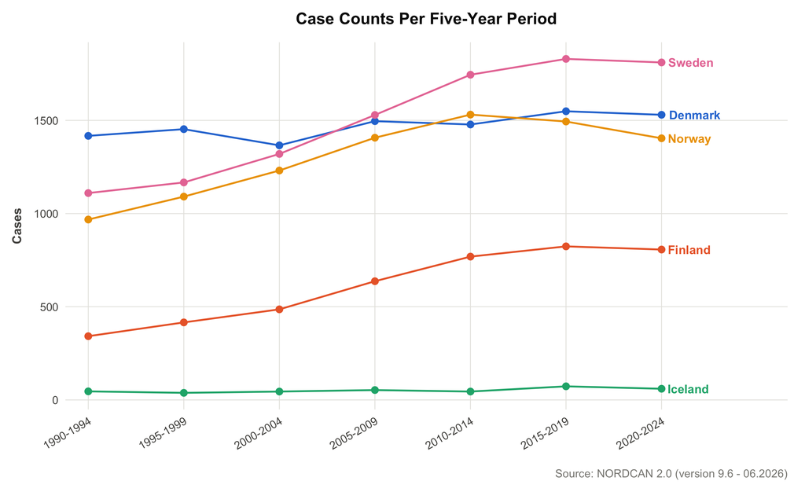

```r
count_labels <- published |>
  group_by(country) |>
  slice_max(period, n = 1) |>
  ungroup()

ggplot(published, aes(period, cases_total,
                      group = country, colour = country)) +
  geom_line(linewidth = 0.7) +
  geom_point(size = 2.2) +
  geom_text(data = count_labels, aes(label = country),
            hjust = -0.15, size = 3.4, fontface = "bold", show.legend = FALSE) +
  scale_colour_manual(values = COUNTRY_COLORS) +
  scale_x_discrete(expand = expansion(mult = c(0.04, 0.22))) +
  labs(title = "Case Counts Per Five-Year Period",
       x = NULL, y = "Cases", caption = SOURCE_NOTE) +
  theme_eda() +
  theme(axis.text.x = element_text(angle = 30, hjust = 1))
```

The gap between the countries is wide and fairly steady. Sweden, Denmark and Norway sit well above the rest, Finland climbs through the middle of the range, and Iceland stays flat along the bottom for the whole period.

```r
published |>
  group_by(country) |>
  summarise(`Fewest Cases` = min(cases_total),
            `Most Cases`   = max(cases_total),
            `Total Cases`  = sum(cases_total),
            .groups = "drop") |>
  arrange(desc(`Total Cases`)) |>
  rename(Country = country)
```

| Country | Fewest Cases | Most Cases | Total Cases |
| --- | --- | --- | --- |
| Sweden | 1110 | 1830 | 10512 |
| Denmark | 1366 | 1549 | 10289 |
| Norway | 968 | 1531 | 9126 |
| Finland | 342 | 824 | 4281 |
| Iceland | 38 | 73 | 360 |

Iceland records between 38 and 73 cases in a period. The other four range from 342 (Finland in 1990–94) up to 1,830 (Sweden in 2015–19). Against the largest contributors that’s roughly 25 times as many cases, though it translates into a smaller difference in precision than that sounds, closer to five times, since a rate’s margin of error narrows with the square root of the count rather than the count itself. Finland sits second from the bottom and bridges the two groups.

The practical upshot is that Iceland’s figures carry real uncertainty, and the modelling stage keeps that uncertainty visible rather than smoothing it over.

# Population Age Structure

Age standardisation exists because countries don’t carry the same mix of ages, and that mix doesn’t hold still over time either. Since this cancer sits mostly in the 25 to 34 range, it is worth seeing how large that slice of the population was at the start of the study window compared with the end.

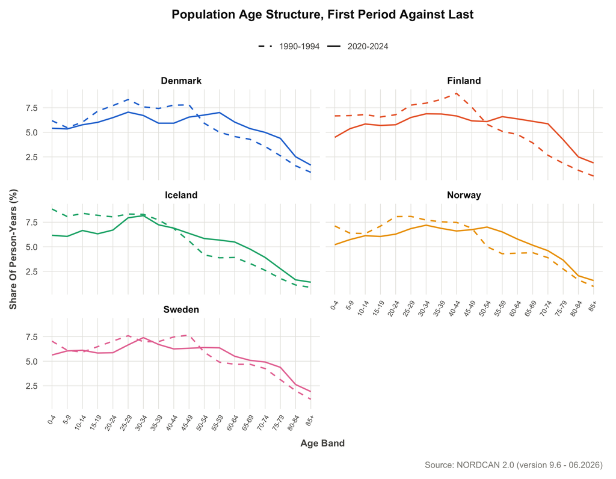

```r
# taken from the data, so a relabelled period cannot silently drop a line
STUDY_PERIODS <- sort(unique(age_specific$period))
FIRST_LAST <- STUDY_PERIODS[c(1, length(STUDY_PERIODS))]

# share rather than headcount, so countries of very different size line up
age_structure <- age_specific |>
  filter(period %in% FIRST_LAST) |>
  group_by(country, period) |>
  mutate(share = person_years / sum(person_years) * 100) |>
  ungroup()

# colour stays with the country, so the two periods are split by line style
ggplot(age_structure, aes(age_band, share,
                          group = period, colour = country, linetype = period)) +
  geom_line(linewidth = 0.7) +
  scale_colour_manual(values = COUNTRY_COLORS) +
  scale_linetype_manual(values = setNames(c("dashed", "solid"), FIRST_LAST)) +
  facet_wrap(~ country, ncol = 2) +
  guides(colour = "none") +
  labs(title = "Population Age Structure, First Period Against Last",
       x = "Age Band", y = "Share Of Person-Years (%)",
       caption = SOURCE_NOTE) +
  theme_eda() +
  theme(legend.position = "top",
        legend.title = element_blank(),
        legend.text = element_text(colour = INK_SOFT, size = 9),
        axis.text.x = element_text(angle = 60, hjust = 1, size = 7))
```

The same shift turns up in all five countries. The share of men under 35 falls everywhere between the two periods, while the share aged 65 and over climbs in return.

```r
age_structure |>
  filter(age_start < 35 | age_start >= 65) |>
  mutate(`Age Group` = ifelse(age_start < 35, "Under 35", "65 And Over")) |>
  group_by(Country = country, `Age Group`, period) |>
  summarise(share = sum(share), .groups = "drop") |>
  pivot_wider(names_from = period, values_from = share) |>
  mutate(Change = .data[[FIRST_LAST[2]]] - .data[[FIRST_LAST[1]]]) |>
  mutate(across(where(is.numeric), \(x) round(x, 1))) |>
  arrange(`Age Group`, desc(Change))
```

| Country | Age Group | 1990-1994 | 2020-2024 | Change |
| --- | --- | --- | --- | --- |
| Finland | 65 And Over | 10.1 | 20.6 | 10.5 |
| Denmark | 65 And Over | 13.0 | 19.0 | 6.0 |
| Iceland | 65 And Over | 9.7 | 14.5 | 4.8 |
| Sweden | 65 And Over | 15.2 | 18.9 | 3.7 |
| Norway | 65 And Over | 13.6 | 17.0 | 3.4 |
| Sweden | Under 35 | 47.2 | 43.6 | -3.6 |
| Denmark | Under 35 | 48.5 | 42.8 | -5.7 |
| Norway | Under 35 | 50.8 | 43.5 | -7.4 |
| Finland | Under 35 | 49.3 | 40.6 | -8.7 |
| Iceland | Under 35 | 58.2 | 48.0 | -10.2 |

Finland’s older share climbs furthest, from 10.1% to 20.6%. Iceland is worth a second look at the other end: it starts with much the youngest profile at 58.2% under 35, still has the youngest profile by 2020–24 at 48.0%, and yet gives up more ground than anyone else along the way.

That matters for the figures further down. A country whose population is drifting out of the 25 to 34 band will see its crude rate drift down with it, even when the risk facing a man of any given age has not moved at all, which is exactly the problem age standardisation is built to take out.

# Age-Specific Rates

Counts on their own can’t be compared across countries, since the populations differ so much. Dividing by person-years puts everyone on the same footing: a rate per 100,000 person-years.

```r
rates <- age_specific |>
  mutate(rate = cases / person_years * 1e5)
```

The first view gives each country its own panel, so the shape of the age curve can be read on its own terms. Each line within a panel is one five-year period.

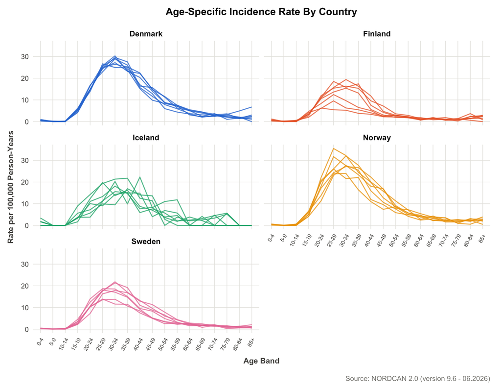

```r
ggplot(rates, aes(age_band, rate, group = period, colour = country)) +
  geom_line(linewidth = 0.6, alpha = 0.75) +
  scale_colour_manual(values = COUNTRY_COLORS) +
  facet_wrap(~ country, ncol = 2) +
  labs(title = "Age-Specific Incidence Rate By Country",
       x = "Age Band", y = "Rate per 100,000 Person-Years",
       caption = SOURCE_NOTE) +
  theme_eda() +
  theme(axis.text.x = element_text(angle = 60, hjust = 1, size = 7))
```

All five follow the same pattern: close to nothing in childhood, a steep climb through the late teens and twenties, a peak in the late twenties or early thirties, then a long decline. The differences between countries are in how high the peak goes, not in where it sits.

Putting all five on one panel makes that height difference easier to compare. Periods are pooled here, so each line is a country’s overall age curve across the full 1990–2024 window.

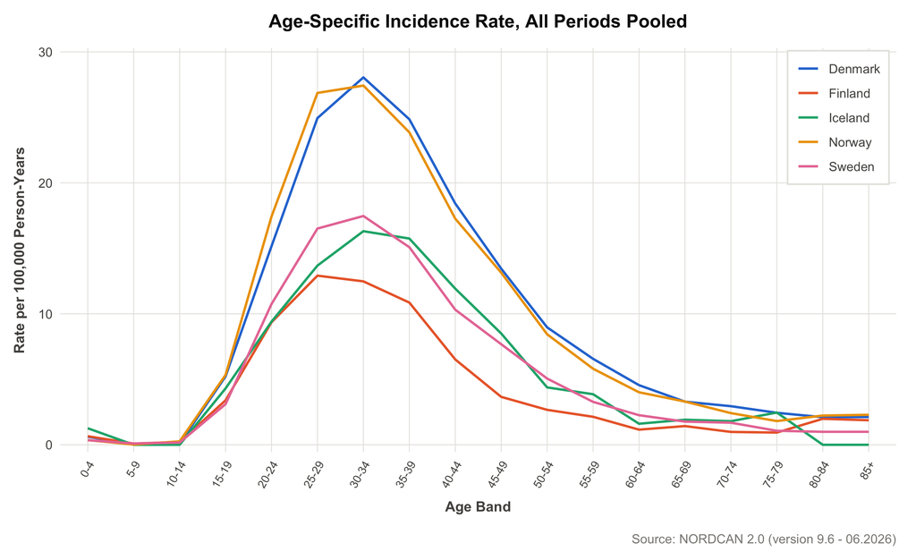

```r
pooled <- rates |>
  group_by(country, age_band, age_start) |>
  summarise(rate = sum(cases) / sum(person_years) * 1e5, .groups = "drop")

ggplot(pooled, aes(age_band, rate, group = country, colour = country)) +
  geom_line(linewidth = 0.8) +
  scale_colour_manual(values = COUNTRY_COLORS) +
  scale_y_continuous(expand = expansion(mult = c(0.02, 0.08))) +
  labs(title = "Age-Specific Incidence Rate, All Periods Pooled",
       x = "Age Band", y = "Rate per 100,000 Person-Years",
       caption = SOURCE_NOTE) +
  theme_eda() +
  legend_corner(0.99, 0.99) +
  theme(axis.text.x = element_text(angle = 60, hjust = 1, size = 8))
```

```r
pooled |>
  group_by(country) |>
  slice_max(rate, n = 1, with_ties = FALSE) |>
  ungroup() |>
  transmute(Country = country,
            `Peak Age Band` = as.character(age_band),
            `Peak Rate` = round(rate, 1)) |>
  arrange(desc(`Peak Rate`))
```

| Country | Peak Age Band | Peak Rate |
| --- | --- | --- |
| Denmark | 30-34 | 28.1 |
| Norway | 30-34 | 27.4 |
| Sweden | 30-34 | 17.5 |
| Iceland | 30-34 | 16.3 |
| Finland | 25-29 | 12.9 |

Denmark and Norway peak highest at around 28 per 100,000. Sweden reaches 17.5 and Iceland 16.3, while Finland is lowest at 12.9, which is less than half the Danish figure. What doesn’t change is when the peak arrives: every country peaks somewhere in the 25 to 34 range. The countries differ in level, not in the age at which the disease appears.

# Small Counts

Not every combination of country, period and age band contains a case. Where those empty cells sit matters, because a rate built on very few cases moves a long way on a single extra case. This section is about locating them before any modelling is done.

```r
zero_cells <- rates |>
  mutate(is_zero = cases == 0) |>
  group_by(country, age_band) |>
  summarise(zeros = sum(is_zero), .groups = "drop")

sum(zero_cells$zeros)
```

```
## [1] 74
```

Of the 630 cells in the dataset, 74 contain no cases at all. The map below shows where they fall. The number inside a square is how many of the seven periods came back empty for that country and age band.

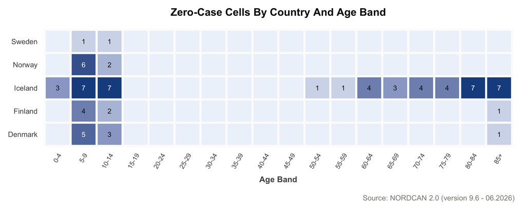

```r
ggplot(zero_cells, aes(age_band, country, fill = zeros)) +
  geom_tile(colour = "#fcfcfb", linewidth = 1.2) +
  geom_text(aes(label = ifelse(zeros > 0, zeros, ""),
                colour = zeros >= 5), size = 3, show.legend = FALSE) +
  scale_colour_manual(values = c(`FALSE` = INK, `TRUE` = "#ffffff")) +
  scale_fill_gradient(low = "#eef3fa", high = "#1a4f8f", limits = c(0, 7)) +
  labs(title = "Zero-Case Cells By Country And Age Band",
       x = "Age Band", y = NULL, caption = SOURCE_NOTE) +
  theme_eda() +
  theme(axis.text.x = element_text(angle = 60, hjust = 1, size = 8),
        panel.grid.major = element_blank())
```

```r
zero_cells |>
  group_by(country) |>
  summarise(`Zero-Case Cells` = sum(zeros), .groups = "drop") |>
  arrange(desc(`Zero-Case Cells`)) |>
  rename(Country = country)
```

| Country | Zero-Case Cells |
| --- | --- |
| Iceland | 48 |
| Denmark | 9 |
| Norway | 8 |
| Finland | 7 |
| Sweden | 2 |

The empties are not spread evenly. Iceland accounts for 48 of the 74 on its own; Sweden has just 2.

```r
zero_cells |>
  group_by(age_band) |>
  summarise(`Zero-Case Cells` = sum(zeros), .groups = "drop") |>
  filter(`Zero-Case Cells` > 0) |>
  arrange(desc(`Zero-Case Cells`)) |>
  rename(`Age Band` = age_band)
```

| Age Band | Zero-Case Cells |
| --- | --- |
| 5-9 | 23 |
| 10-14 | 15 |
| 85+ | 9 |
| 80-84 | 7 |
| 60-64 | 4 |
| 70-74 | 4 |
| 75-79 | 4 |
| 0-4 | 3 |
| 65-69 | 3 |
| 50-54 | 1 |
| 55-59 | 1 |

By age, they cluster at the two ends of the range, in the childhood bands and the oldest bands, which are exactly the ages where this cancer is least common. Those bands carry little weight once rates are age-standardised, so their effect on the headline figures is limited. Iceland’s wider uncertainty, on the other hand, carries through and stays visible in the modelling stage.

# Crude Rate Over Time

Crude rates are the simplest possible summary: total cases divided by total person-years, with no adjustment for the fact that countries have different age profiles. They’re a useful orientation, but they aren’t the comparison this project is built to make. That one comes later, once rates are age-standardised.

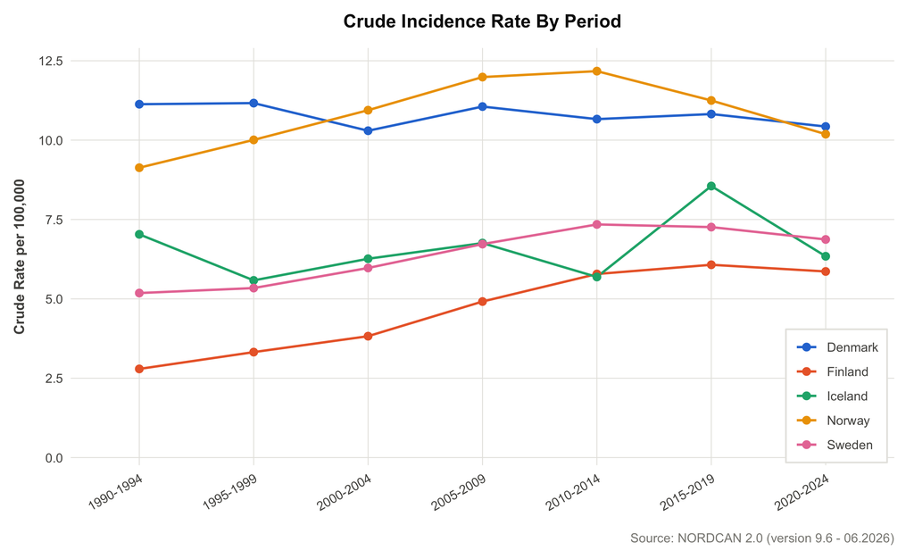

```r
ggplot(published, aes(period, crude_rate, group = country, colour = country)) +
  geom_line(linewidth = 0.8) +
  geom_point(size = 2.2) +
  scale_colour_manual(values = COUNTRY_COLORS) +
  scale_y_continuous(limits = c(0, NA),
                     expand = expansion(mult = c(0.02, 0.06))) +
  labs(title = "Crude Incidence Rate By Period",
       x = NULL, y = "Crude Rate per 100,000", caption = SOURCE_NOTE) +
  theme_eda() +
  legend_corner(0.99, 0.01) +
  theme(axis.text.x = element_text(angle = 30, hjust = 1))
```

Denmark starts highest and stays fairly flat. Norway, Sweden and Finland all climb over the period, with Norway overtaking Denmark in the middle years before easing back. Iceland moves around far more than the others from period to period, which is what forty to seventy cases will do to a rate.

```r
published |>
  group_by(period) |>
  summarise(`Lowest Rate`       = min(crude_rate),
            `Highest Rate`      = max(crude_rate),
            `High-To-Low Ratio` = max(crude_rate) / min(crude_rate),
            .groups = "drop") |>
  mutate(across(where(is.numeric), \(x) round(x, 2))) |>
  rename(Period = period)
```

| Period | Lowest Rate | Highest Rate | High-To-Low Ratio |
| --- | --- | --- | --- |
| 1990-1994 | 2.79 | 11.13 | 3.99 |
| 1995-1999 | 3.32 | 11.17 | 3.36 |
| 2000-2004 | 3.82 | 10.94 | 2.86 |
| 2005-2009 | 4.92 | 11.99 | 2.44 |
| 2010-2014 | 5.69 | 12.17 | 2.14 |
| 2015-2019 | 6.07 | 11.25 | 1.85 |
| 2020-2024 | 5.86 | 10.43 | 1.78 |

The ratio is worked out fresh for each period, comparing whichever countries are highest and lowest at that point rather than fixing on one pair. On crude rates the gap narrows steadily across the study window, from about four times in the early 1990s to under two times by 2020–24. Whether that still holds once age differences are accounted for is the question the modelling stage is set up to answer, so nothing here is the final word on it.